# Announcements

Be sure to check this page regularly for updates. In addition to periodic updates about the course, slides and recordings of the weekly meetups will be posted here.

[figure not shown]

### Meetup 15: Deep Learning

Click here to read more about Meetup 15 and view/download the lecture slides.

May 12, 2025

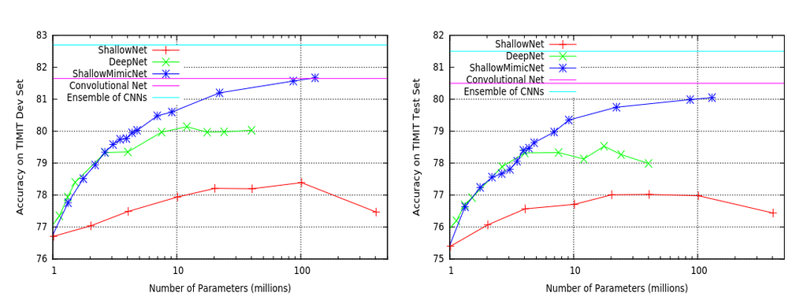

### Week 15- Deep Learning

Click here to read about Week 15.

May 11, 2025

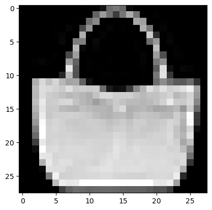

### Meetup 14: Neural Networks

Click here to read more about Meetup 14 and view/download the lecture slides.

May 8, 2025

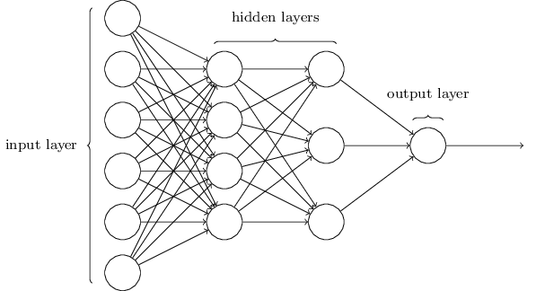

### Week 14- Optimization Algorithms

Click here to read about Week 14.

May 7, 2025

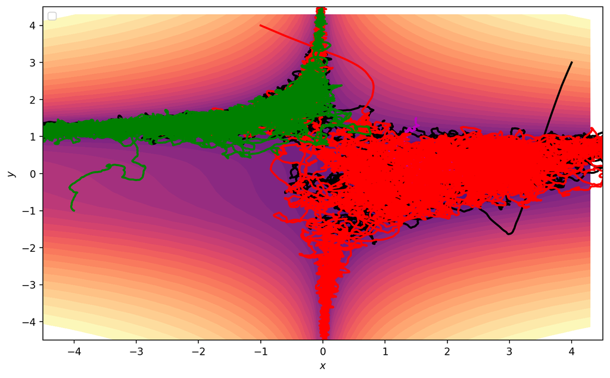

### Meetup 13: Non-Convex Optimization

Click here to read more about Meetup 13 and view/download the lecture slides.

Apr 28, 2025

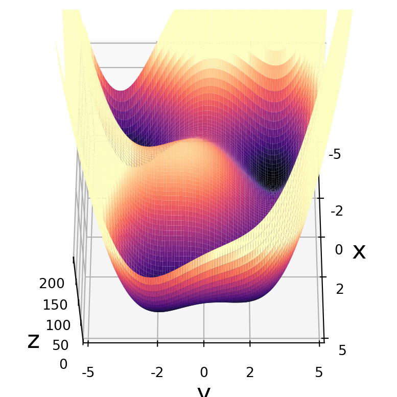

### Week 13- Optimization Algorithms

Click here to read about Week 13.

Apr 28, 2025

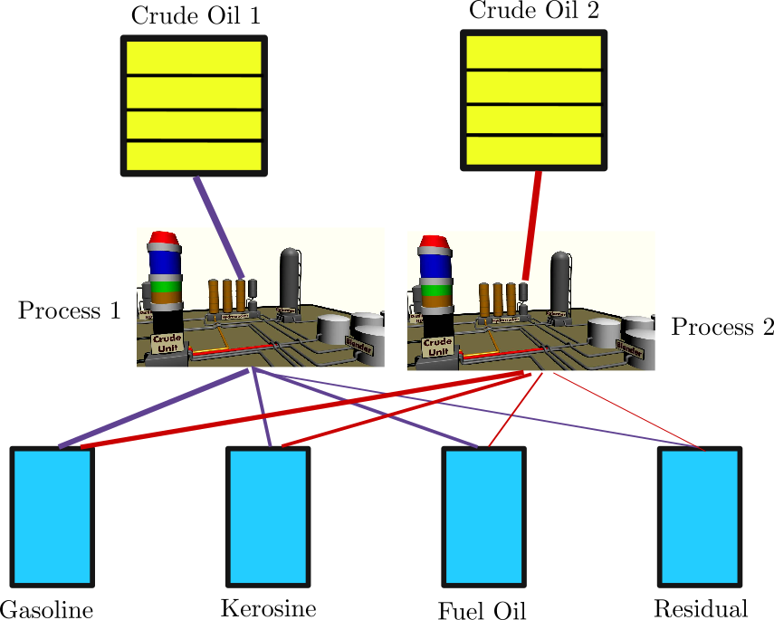

### Meetup 12: Duality

Click here to read more about Meetup 12 and view/download the lecture slides.

Apr 21, 2025

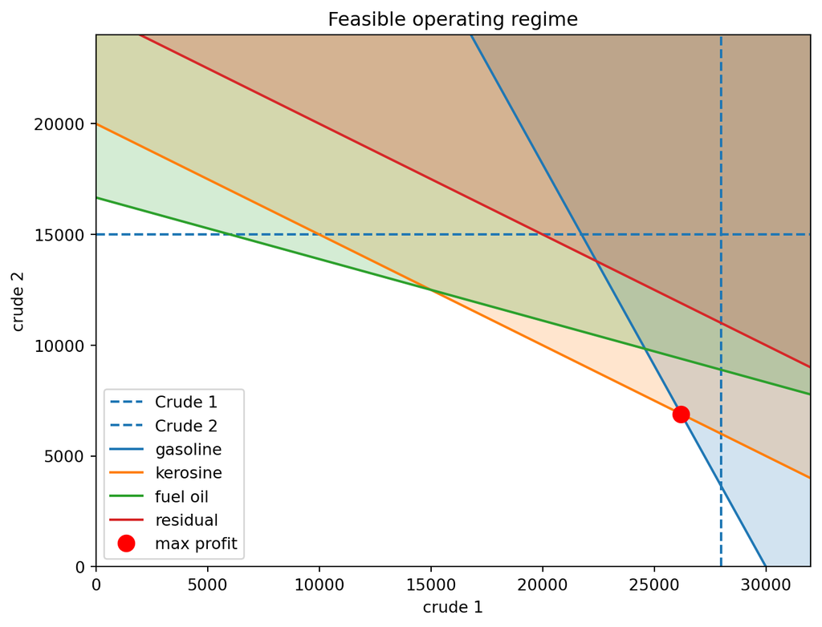

### Week 12- Duality

Click here to read about Week 12.

Apr 20, 2025

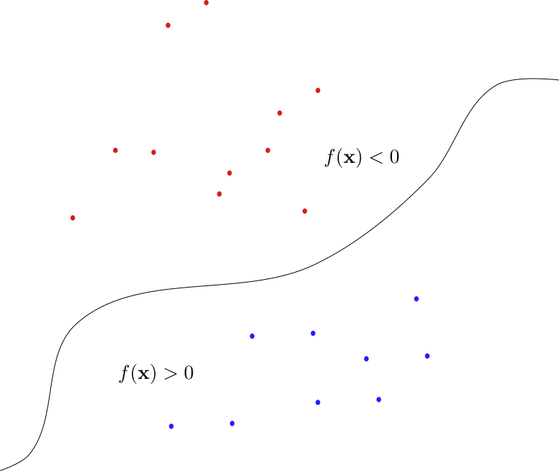

### Week 11- Stats and Machine Learning

Click here to read about Week 11.

Apr 7, 2025

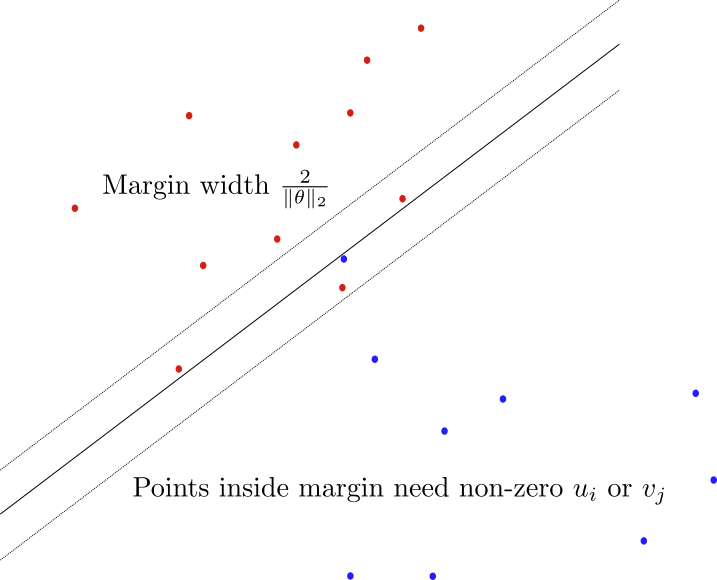

### Meetup 11: Statistics

Click here to read more about Meetup 11 and view/download the lecture slides.

Apr 7, 2025

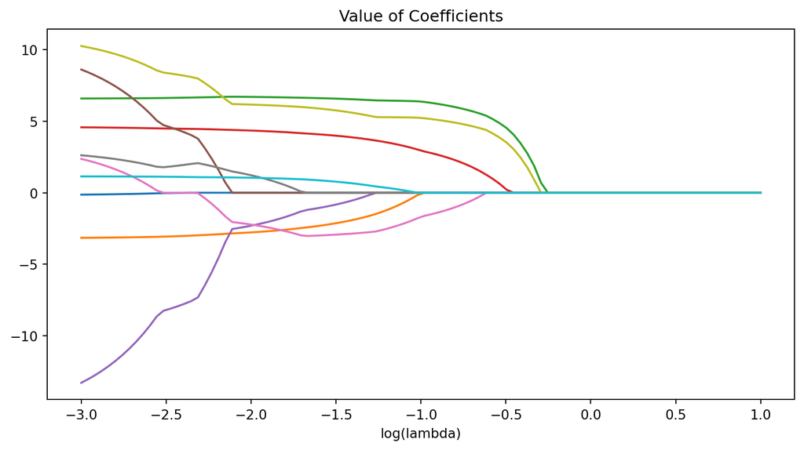

### Meetup 10: Data Fitting

Click here to read more about Meetup 10 and view/download the lecture slides.

Apr 1, 2025

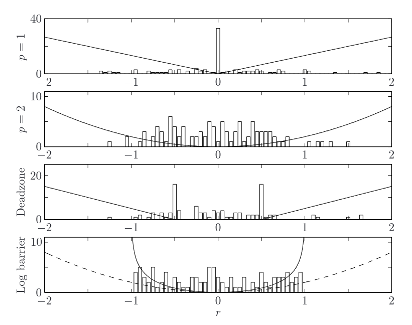

### Week 10- Data Fitting

Click here to read about Week 10.

Mar 31, 2025

[figure not shown]

### Meetup 9: Convex Optimization Problems

Click here to read more about Meetup 9 and view/download the lecture slides.

Mar 24, 2025

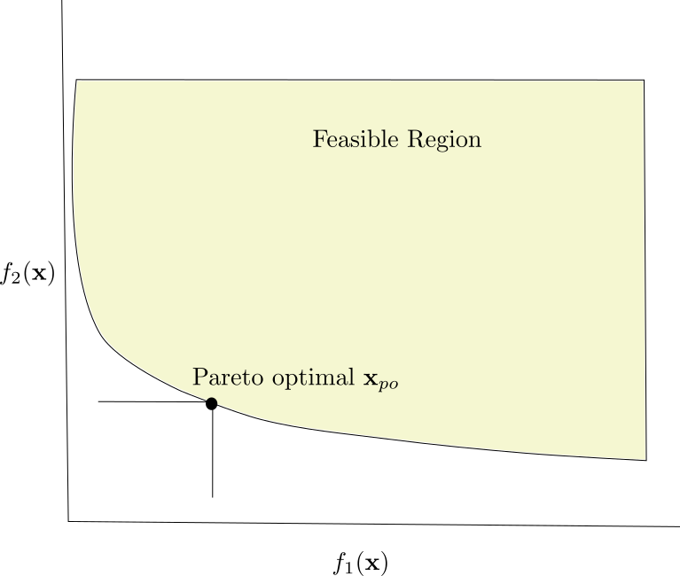

### Week 9- Convex Optimization Problems

Click here to read about Week 9.

Mar 24, 2025

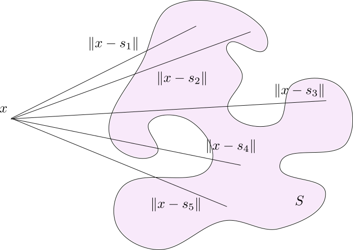

### Week 8- Convex Functions

Click here to read about Week 8.

Mar 18, 2025

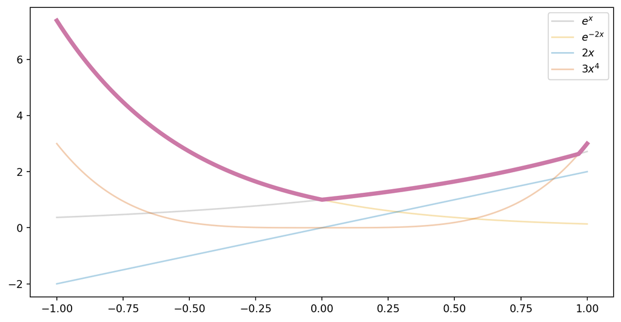

### Meetup 8: Constructing Convex Functions

Click here to read more about Meetup 8 and view/download the lecture slides.

Mar 18, 2025

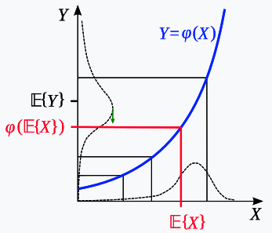

Click here to read more about Meetup 7 and view/download the lecture slides.

Mar 10, 2025

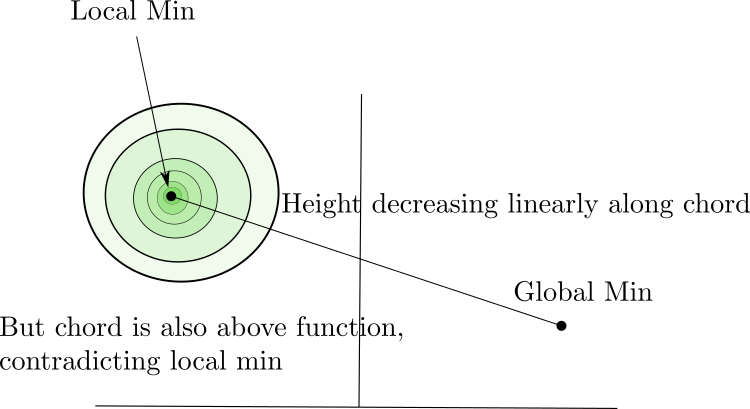

### Week 7- Convex Functions

Click here to read about Week 7.

Mar 10, 2025

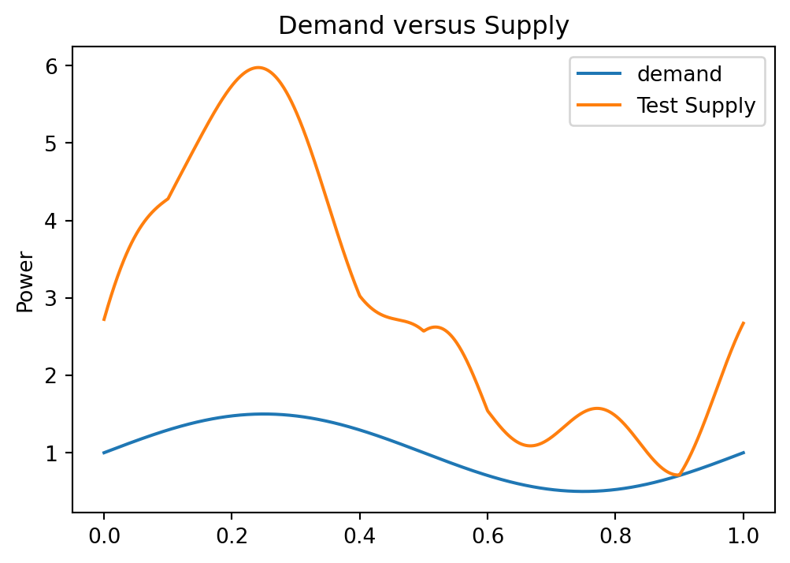

### Meetup 6: Introduction to Convex Sets

Click here to read more about Meetup 6 and view/download the lecture slides.

Mar 4, 2025

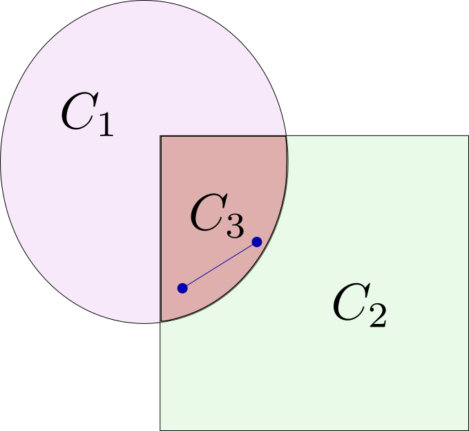

### Week 6- Constructing Convex Sets

Click here to read about Week 6.

Mar 3, 2025

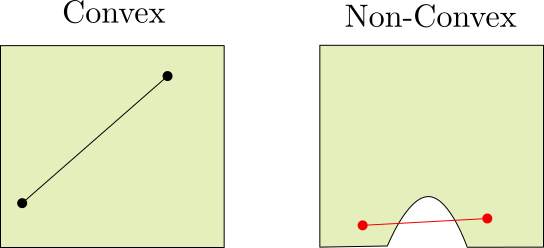

### Week 5-Convex Sets

Click here to read about Week 5.

Feb 24, 2025

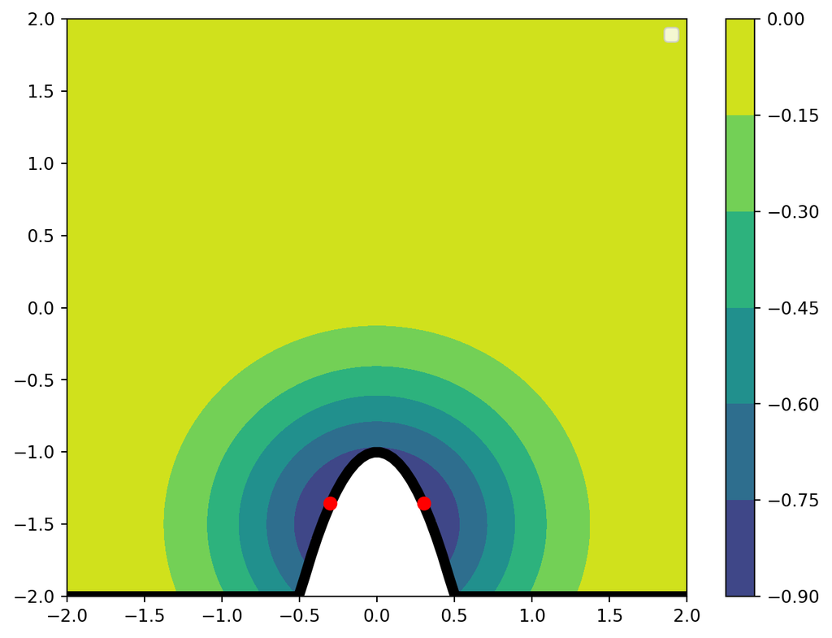

### Meetup 5: Introduction to Convex Sets

Click here to read more about Meetup 5 and view/download the lecture slides.

Feb 17, 2025

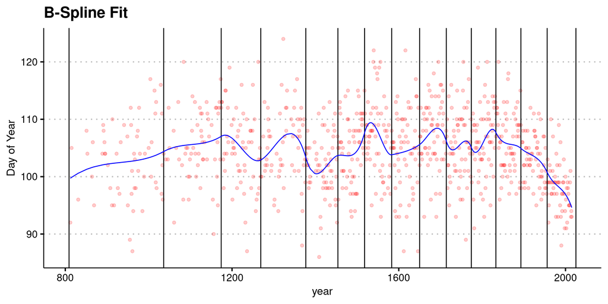

### Meetup 4: Least Squares Data Fitting

Click here to read more about Meetup 4 and view/download the lecture slides.

Feb 17, 2025

[figure not shown]

### Week 4- Constrained Least Squares

Feb 16, 2025

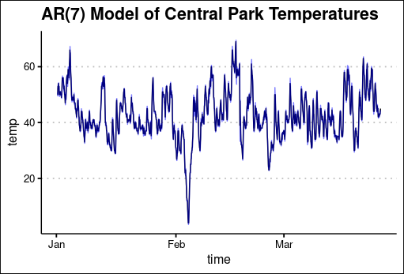

### Coding Vignette- Linear Algebra in R

Click here for a video on basic linear algebra in R.

Feb 14, 2025

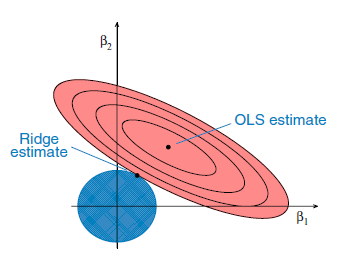

### Meetup 3: Least Squares Data Fitting

Click here to read more about Meetup 3 and view/download the lecture slides.

Feb 10, 2025

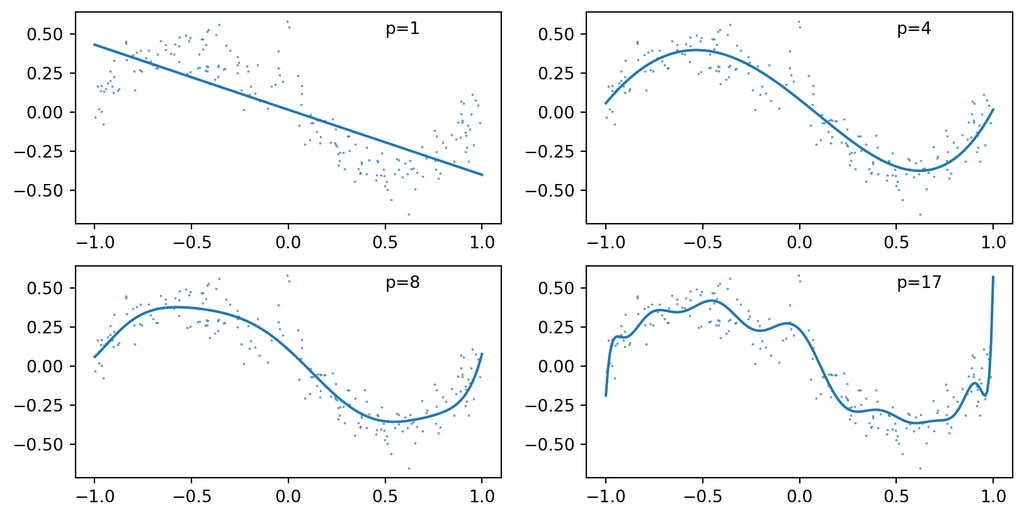

### Week 3- Data Fitting

Click here to read about Week 3.

Feb 9, 2025

[figure not shown]

### Coding Vignette- Writing Math in Markdown

Click here for a 20 minute video on writing math in markdown using Latex.

Feb 5, 2025

[figure not shown]

### Coding Vignette- Linear Algebra in Numpy

Click here for a video on basic linear algebra in Numpy.

Feb 5, 2025

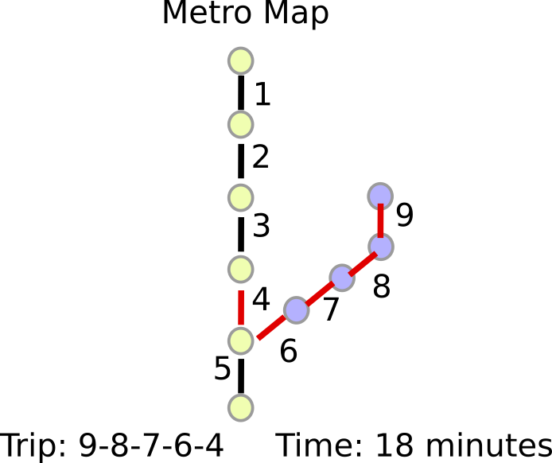

### Meetup 2: Least Squares Optimization

Click here to read more about Meetup 2 and view/download the lecture slides.

Feb 3, 2025

[figure not shown]